# A Comparison of Pandas and SQL

## Working with SQL and Pandas in Python

This atricle illustrates how to connect to a SQL Database and make queries through Python, as well as comparing how equivalent operations would be perfomred in Pandas. As usual, I'll start by bringing in a few libraries. Note that each SQL platform(Sqlite3, MySQL, PostgreSQL, etc) each have their own library to interface with Python.

```python
import sqlite3 as sql
import pandas as pd
from pandas import DataFrame, Series
```

#### And, since we're looking at a lot of DataFrames in this article, a little formatting:

```python
CSS = """
body {
    margin: 0;
    font-family: Helvetica;
}
table.dataframe {
    border-collapse: collapse;
    border: none;
}
table.dataframe tr {
    border: none;
}
table.dataframe td, table.dataframe th {
    margin: 0;
    border: 1px solid white;
    padding-left: 0.25em;
    padding-right: 0.25em;
}
table.dataframe th:not(:empty) {
    background-color: #fec;
    text-align: left;
    font-weight: normal;
}
table.dataframe tr:nth-child(2) th:empty {
    border-left: none;
    border-right: 1px dashed #888;
}
table.dataframe td {
    border: 2px solid #ccf;
    background-color: #f4f4ff;
}
"""
from IPython.core.display import HTML
HTML('<style>{}</style>'.format(CSS))
```

### Schema:

#### This article will use the chinook database, a free Open Source Database containing itunes music purchase information. I'm not going to include the enitre schema since table heads will be visible in the DataFrames below, but the the full list ofTables in the Database are:

sqlite> .table

- Album
- Employee
- InvoiceLine
- PlaylistTrack
- Artist
- Genre
- MediaType
- Track
- Customer
- Invoice
- Playlist

#### Once the correct SQL library has been loaded, it's pretty straigforward to instantiate a cursor object to perform queries. Here's the simplest Query I can think of - selecting an entire table:

```python
db = sql.connect("chinook.db")  #connect to the database
c = db.cursor()                 #and instantiate a cursor

QUERY = '''SELECT * FROM Customer''' #Store the Query string in the QUERY variable

c.execute(QUERY)

Customer = DataFrame(c.fetchall(), columns = ['CustomerId',
    'FirstName',
    'LastName',
    'Company',
    'Address',
    'City',
    'State',
    'Country',
    'PostalCode',
    'Phone',
    'Fax',
    'Email',
    'SupportRepId'])
Customer.head()
```

|  | CustomerId | FirstName | LastName | Company | Address | City | State | Country | PostalCode | Phone | Fax | Email | SupportRepId |
| --- | --- | --- | --- | --- | --- | --- | --- | --- | --- | --- | --- | --- | --- |
| 0 | 1 | Luís | Gonçalves | Embraer - Empresa Brasileira de Aeronáutica S.A. | Av. Brigadeiro Faria Lima, 2170 | São José dos Campos | SP | Brazil | 12227-000 | +55 (12) 3923-5555 | +55 (12) 3923-5566 | luisg@embraer.com.br | 3 |
| 1 | 2 | Leonie | Köhler | None | Theodor-Heuss-Straße 34 | Stuttgart | None | Germany | 70174 | +49 0711 2842222 | None | leonekohler@surfeu.de | 5 |
| 2 | 3 | François | Tremblay | None | 1498 rue Bélanger | Montréal | QC | Canada | H2G 1A7 | +1 (514) 721-4711 | None | ftremblay@gmail.com | 3 |
| 3 | 4 | Bjørn | Hansen | None | Ullevålsveien 14 | Oslo | None | Norway | 0171 | +47 22 44 22 22 | None | bjorn.hansen@yahoo.no | 4 |
| 4 | 5 | František | Wichterlová | JetBrains s.r.o. | Klanova 9/506 | Prague | None | Czech Republic | 14700 | +420 2 4172 5555 | +420 2 4172 5555 | frantisekw@jetbrains.com | 4 |

#### If I wanted to subset the data in Pandas I'd just select the columns I needed to work with:

```python
Customer = Customer[['CustomerId','Country']]
Customer.head()
```

|  | CustomerId | Country |
| --- | --- | --- |
| 0 | 1 | Brazil |
| 1 | 2 | Germany |
| 2 | 3 | Canada |
| 3 | 4 | Norway |
| 4 | 5 | Czech Republic |

#### Or, I could have specicfed the columns in the original Query:

```python
QUERY = '''SELECT CustomerId, Country FROM Customer'''
c.execute(QUERY)
Customer = DataFrame(c.fetchall(), columns = ['CustomerId','Country'])
Customer.head()
```

|  | CustomerId | Country |
| --- | --- | --- |
| 0 | 1 | Brazil |
| 1 | 2 | Germany |
| 2 | 3 | Canada |
| 3 | 4 | Norway |
| 4 | 5 | Czech Republic |

#### Now suppose I wanted a summary of the 10 countries with the most customers? In Pandas I can use groupby and an agg function:

```python
countries = Customer.groupby('Country')['CustomerId'].count().sort_values(ascending = False)

countries.head(10)
```

```
Country
USA               13
Canada             8
Brazil             5
France             5
Germany            4
United Kingdom     3
Czech Republic     2
India              2
Portugal           2
Norway             1
Name: CustomerId, dtype: int64
```

#### The equivalent using SQL to make this query directly to the database would be:

```python
QUERY = ''' SELECT Country, count(CustomerId) as  customers FROM Customer
            GROUP BY Country
            ORDER BY customers DESC
            LIMIT 10
            '''
c.execute(QUERY)
countries = DataFrame(c.fetchall(), columns = ['Country','Customers'])
countries
```

|  | Country | Customers |
| --- | --- | --- |
| 0 | USA | 13 |
| 1 | Canada | 8 |
| 2 | Brazil | 5 |
| 3 | France | 5 |
| 4 | Germany | 4 |
| 5 | United Kingdom | 3 |
| 6 | Czech Republic | 2 |
| 7 | India | 2 |
| 8 | Portugal | 2 |
| 9 | Argentina | 1 |

- Note that Pandas and SQL have different default behaviors for ties. Pandas maintains it's index order and returns Norway as the 10th Country whereas the SQL query sorts ties alphabetically by Country and returns Argentina.

#### Now I'll look at a more complicated query involving a subquery. Let's find out how many unique customers in the database have purchased a Jazz track. SQL First:

```python
QUERY = ''' SELECT count(ID) from(SELECT Invoice.CustomerId as ID from Invoice
            JOIN InvoiceLine ON InvoiceLine.InvoiceId = Invoice.InvoiceID
            JOIN Track ON Track.TrackID = InvoiceLine.TrackID
            JOIN Genre ON Genre.GenreID = Track.GenreID
            WHERE Genre.Name = "Jazz"
            GROUP BY Invoice.CustomerID) as sub;
         '''
c.execute(QUERY)
#df = pd.DataFrame(c.fetchall())
c.fetchall()
```

```
[(32,)]
```

#### So 32 Customer have purchased a Jazz Track. In order to perform the same search in Pandas I first have to load all the tables into DataFrames. I'll show the head of each one for clarity:

```python
#Pull the Track Table into a DataFrame
QUERY = '''SELECT * FROM Track

        '''
c.execute(QUERY)
Track = DataFrame(c.fetchall(),columns = [ 'TrackId',
                                            'Name',
                                            'AlbumId',
                                            'MediaTypeId',
                                            'GenreId',
                                            'Composer',
                                            'Milliseconds',
                                            'Bytes',
                                            'UnitPrice'])
Track.head()
```

|  | TrackId | Name | AlbumId | MediaTypeId | GenreId | Composer | Milliseconds | Bytes | UnitPrice |
| --- | --- | --- | --- | --- | --- | --- | --- | --- | --- |
| 0 | 1 | For Those About To Rock (We Salute You) | 1 | 1 | 1 | Angus Young, Malcolm Young, Brian Johnson | 343719 | 11170334 | 0.99 |
| 1 | 2 | Balls to the Wall | 2 | 2 | 1 | None | 342562 | 5510424 | 0.99 |
| 2 | 3 | Fast As a Shark | 3 | 2 | 1 | F. Baltes, S. Kaufman, U. Dirkscneider & W. Ho... | 230619 | 3990994 | 0.99 |
| 3 | 4 | Restless and Wild | 3 | 2 | 1 | F. Baltes, R.A. Smith-Diesel, S. Kaufman, U. D... | 252051 | 4331779 | 0.99 |
| 4 | 5 | Princess of the Dawn | 3 | 2 | 1 | Deaffy & R.A. Smith-Diesel | 375418 | 6290521 | 0.99 |

```python
#Pull the Genre Table into a DataFrame
QUERY = '''SELECT * FROM Genre

        '''
c.execute(QUERY)
Genre = DataFrame(c.fetchall(),columns = ['GenreId', 'Name'])
Genre.head()
```

|  | GenreId | Name |
| --- | --- | --- |
| 0 | 1 | Rock |
| 1 | 2 | Jazz |
| 2 | 3 | Metal |
| 3 | 4 | Alternative & Punk |
| 4 | 5 | Rock And Roll |

```python
#Pull the InvoiceLine Table into a DataFrame
QUERY = '''SELECT * FROM InvoiceLine

        '''
c.execute(QUERY)
InvoiceLine = DataFrame(c.fetchall(),columns = ['InvoiceLineId',
    'InvoiceId',
    'TrackId',
    'UnitPrice',
    'Quantity'])
InvoiceLine.head()
```

|  | InvoiceLineId | InvoiceId | TrackId | UnitPrice | Quantity |
| --- | --- | --- | --- | --- | --- |
| 0 | 1 | 1 | 2 | 0.99 | 1 |
| 1 | 2 | 1 | 4 | 0.99 | 1 |
| 2 | 3 | 2 | 6 | 0.99 | 1 |
| 3 | 4 | 2 | 8 | 0.99 | 1 |
| 4 | 5 | 2 | 10 | 0.99 | 1 |

```python
#Pull the Invoice Table into a DataFrame
QUERY = '''SELECT * FROM Invoice

        '''
c.execute(QUERY)
Invoice = DataFrame(c.fetchall(),columns = ['InvoiceId',
    'CustomerId',
    'InvoiceDate',
    'BillingAddress',
    'BillingCity',
    'BillingState',
    'BillingCountry',
    'BillingPostalCode',
    'Total'])
Invoice.head()
```

|  | InvoiceId | CustomerId | InvoiceDate | BillingAddress | BillingCity | BillingState | BillingCountry | BillingPostalCode | Total |
| --- | --- | --- | --- | --- | --- | --- | --- | --- | --- |
| 0 | 1 | 2 | 2009-01-01 00:00:00 | Theodor-Heuss-Straße 34 | Stuttgart | None | Germany | 70174 | 1.98 |
| 1 | 2 | 4 | 2009-01-02 00:00:00 | Ullevålsveien 14 | Oslo | None | Norway | 0171 | 3.96 |
| 2 | 3 | 8 | 2009-01-03 00:00:00 | Grétrystraat 63 | Brussels | None | Belgium | 1000 | 5.94 |
| 3 | 4 | 14 | 2009-01-06 00:00:00 | 8210 111 ST NW | Edmonton | AB | Canada | T6G 2C7 | 8.91 |
| 4 | 5 | 23 | 2009-01-11 00:00:00 | 69 Salem Street | Boston | MA | USA | 2113 | 13.86 |

#### So I now have all the tables used in the query loaded into DataFrames. Remember that the question is how many unique customers bought Jazz Tracks. There are a couple of different ways I can do this in Pandas. First, I'll use merge, similar to the SQL JOIN command:

```python
data = Invoice.merge(InvoiceLine, on = 'InvoiceId')
data = data.merge(Track, on = 'TrackId')
data = data.merge(Genre, on = 'GenreId')

data.head()
```

|  | InvoiceId | CustomerId | InvoiceDate | BillingAddress | BillingCity | BillingState | BillingCountry | BillingPostalCode | Total | InvoiceLineId | ... | Quantity | Name_x | AlbumId | MediaTypeId | GenreId | Composer | Milliseconds | Bytes | UnitPrice_y | Name_y |
| --- | --- | --- | --- | --- | --- | --- | --- | --- | --- | --- | --- | --- | --- | --- | --- | --- | --- | --- | --- | --- | --- |
| 0 | 1 | 2 | 2009-01-01 00:00:00 | Theodor-Heuss-Straße 34 | Stuttgart | None | Germany | 70174 | 1.98 | 1 | ... | 1 | Balls to the Wall | 2 | 2 | 1 | None | 342562 | 5510424 | 0.99 | Rock |
| 1 | 214 | 33 | 2011-07-25 00:00:00 | 5112 48 Street | Yellowknife | NT | Canada | X1A 1N6 | 8.91 | 1154 | ... | 1 | Balls to the Wall | 2 | 2 | 1 | None | 342562 | 5510424 | 0.99 | Rock |
| 2 | 1 | 2 | 2009-01-01 00:00:00 | Theodor-Heuss-Straße 34 | Stuttgart | None | Germany | 70174 | 1.98 | 2 | ... | 1 | Restless and Wild | 3 | 2 | 1 | F. Baltes, R.A. Smith-Diesel, S. Kaufman, U. D... | 252051 | 4331779 | 0.99 | Rock |
| 3 | 2 | 4 | 2009-01-02 00:00:00 | Ullevålsveien 14 | Oslo | None | Norway | 0171 | 3.96 | 3 | ... | 1 | Put The Finger On You | 1 | 1 | 1 | Angus Young, Malcolm Young, Brian Johnson | 205662 | 6713451 | 0.99 | Rock |
| 4 | 2 | 4 | 2009-01-02 00:00:00 | Ullevålsveien 14 | Oslo | None | Norway | 0171 | 3.96 | 4 | ... | 1 | Inject The Venom | 1 | 1 | 1 | Angus Young, Malcolm Young, Brian Johnson | 210834 | 6852860 | 0.99 | Rock |

5 rows × 22 columns

#### This results in one merged dataframe containing all the data from the four DataFrames "Genre", "Track", "InvoiceLine", and "Invoice". Note that the duplicate column names have been renamed, and there are now multiple lines for the same InvoiceId. Once the DataFrames are merged, it's pretty easy to pull the unique customer count out:

```python
Jazz = data[data.Name_y == 'Jazz']
len(Jazz.CustomerId.unique())
```

```
32
```

Another approach, If you did not want to merge all of the DataFrames, would be to filter through them sequentially for the same result:

```python
#Filter through the DataFrames:
jazzId = int(Genre[Genre.Name == 'Jazz'].GenreId)
JazzTracks = Track[Track.GenreId == jazzId]
JazzInvoiceLines = InvoiceLine[InvoiceLine.TrackId.isin(JazzTracks.TrackId)]
JazzInvoices = Invoice[Invoice.InvoiceId.isin(JazzInvoiceLines.InvoiceId)]

#and count the unique customers:
len(JazzInvoices.CustomerId.unique())
```

```
32
```

#### And I get the same answer as the SQL query above.

### And here are just a couple more examples of summarizing Queries using Subqueries:

- What Genres have the most songs with below average song length?

#### I could do this with two Queries. One to find the average song length:

```python
QUERY = '''SELECT Avg(Milliseconds) as average FROM Track'''
c.execute(QUERY)
average = c.fetchall()[0][0] #fetchall returns a list of tuples, so I need to index in if I want to get the average value
average = int(average)
average
```

```
393599
```

#### And a second query to sum the number of songs with shorter time than average.

```python
QUERY = ''' SELECT Genre.name, count(Genre.name) as num FROM Genre
            JOIN Track ON Genre.GenreID = Track.GenreID
            WHERE Track.Milliseconds < ?
            GROUP BY Genre.Name
            ORDER BY num DESC
            Limit 10;
         '''
c.execute(QUERY, (average,))  #Note that the QUERY wants my variable tuple form.
#df = pd.DataFrame(c.fetchall())
songlength = DataFrame(c.fetchall(), columns = ['Genre', 'AverageLength'])
songlength
```

|  | Genre | AverageLength |
| --- | --- | --- |
| 0 | Rock | 1162 |
| 1 | Latin | 569 |
| 2 | Alternative & Punk | 320 |
| 3 | Metal | 300 |
| 4 | Jazz | 116 |
| 5 | Blues | 72 |
| 6 | Classical | 60 |
| 7 | R&B/Soul | 60 |
| 8 | Reggae | 58 |
| 9 | Pop | 46 |

#### Or, I could just combine the two with the average value calculation as a subQuery:

```python
QUERY = ''' SELECT Genre.name, count(Genre.name) as num FROM Genre,
                (SELECT Avg(Milliseconds) as average FROM Track) AS sub
            JOIN Track ON Genre.GenreID = Track.GenreID
            WHERE Track.Milliseconds < average
            GROUP BY Genre.Name
            ORDER BY num DESC
            Limit 10;
         '''
c.execute(QUERY)
#df = pd.DataFrame(c.fetchall())
songlength = DataFrame(c.fetchall(), columns = ['Genre', 'AverageLength'])
songlength
```

|  | Genre | AverageLength |
| --- | --- | --- |
| 0 | Rock | 1162 |
| 1 | Latin | 569 |
| 2 | Alternative & Punk | 320 |
| 3 | Metal | 300 |
| 4 | Jazz | 116 |
| 5 | Blues | 72 |
| 6 | Classical | 60 |
| 7 | R&B/Soul | 60 |
| 8 | Reggae | 58 |
| 9 | Pop | 46 |

#### And of course, once the data is in a DataFrame all the analysis and visualization tools of Python become available:

```python
import matplotlib.pyplot as plt
%matplotlib inline
```

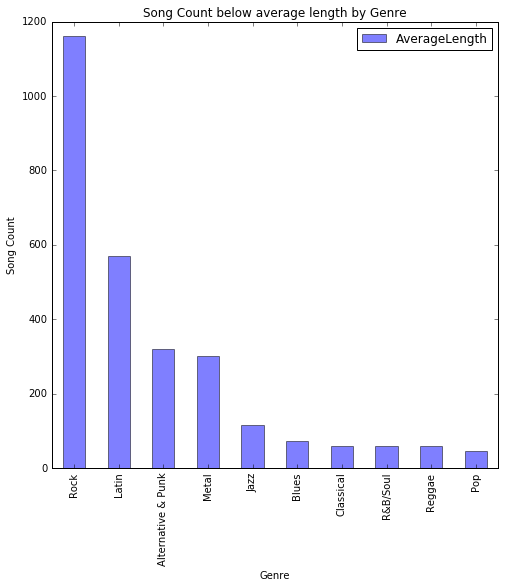

```python
songlength.plot.bar(x = 'Genre', alpha = .5, figsize = (8,8))
plt.ylabel('Song Count')
plt.title('Song Count below average length by Genre')
plt.show()
```

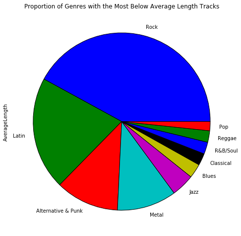

```python
songlength.plot.pie(x = "Genre", y = "AverageLength", labels = songlength.Genre, figsize=(8,8))
plt.legend().set_visible(False)
plt.title("Proportion of Genres with the Most Below Average Length Tracks")
```

### Conclusion:

I put this notebook together to illustrate some of the similarities and differences between Pandas filtering and aggregation and SQL Queries, as well as to illustrate a simple interaction between SQL and Python. One of the main take away points to me is how much a SQL database can help streamline an analysis by querying out the pertinent information. This can help make your code simpler and more readable. Also, performing Database queries can be much faster and less memory intense compared to the equivalent operations in Pandas. Conversely, once the data has been brought into a DataFrame all of the analysis and visualization tools of Python become available. Thanks for reading!